# Enchroachment LiDAR

Authors

Affiliation

Ida M. Mienna

The Norwegian Institute for Nature Research (NINA)

Zander Venter

The Norwegian Institute for Nature Research (NINA)

Published

August 12, 2024

```
[1] "/data/P-Prosjekter2/412421_okologisk_tilstand_2024/Ida/ecRxiv_gjengroing"
```

**Status**

This indicator documentation is incomplete and needs further developement before indicator values can be calculated.

**Recomended citation**

**Version**

000.001

Table 1: Indicator metadata

| Indicator ID | NO_GJEN_001 |
| --- | --- |
| Indicator Name | Gjengroing |
| Country | Norway |
| Continent | Europe |
| Ecosystem Condition Typology Class | B3 - Functional State Characteristics |
| Realm | Terrestrial (T) |
| Biome | T3 Shrublands and shrubby woodlands biome |
| Ecosystem | T3.3 Cool temp heathlands |
| Year added | 2024 |
| Last update | 2024 |
| status | incomplete |
| Version | 000.001 |
| Version comment | NA |
| url | https://github.com/NINAnor/ecRxiv |

# Gjengroing

## 1. Introduction

From [ecosystemCondition](https://github.com/NINAnor/ecosystemCondition/blob/main/gjengroing.Rmd):

“The Norwegian word”gjengroing” is directly translated to “regrowing” in English. The gjengroing indicator describes the regrowth of woody vegetation (trees and bushes) in open ecosystems (wetland, semi- and naturally open areas) across Norway. We will use a spatial reference approach where reference areas define good or optimal vegetation regrowth heights.

The workflow spans two platforms including RStudio and Google Earth Engine (GEE). To reproduce this workflow you will need a GEE account and access to the NINA RStudio and R/GeoSpatialData servers.”

## 2. About the underlying data

From [ecosystemCondition](https://github.com/NINAnor/ecosystemCondition/blob/main/gjengroing.Rmd):

“We rely on the following datasets:

- [Nature type polygons](https://kartkatalog.miljodirektoratet.no/Dataset/Details/2031) are used to identify reference areas with good ecological condition.
- NIBIO’s [AR5](https://kartkatalog.geonorge.no/metadata/arealressurskart-fkb-ar5-arealtyper/280bbd7a-5ce9-4c83-9e15-ac162cabd8a6) is used as the population sample for each ecosystem type. The population sample are the areas used to determine ecological condition relative to the reference areas. We also use the AR5 data to identify forest surrounding the population polygons for defining the lower limit of ecological condition index (i.e.. poor condition),
- LiDAR-derived digital elevation model from Kartverket’s [høydedata](https://hoydedata.no/LaserInnsyn/). This includes both a terrain (DTM) and surface model (DSM). We calculate the canopy height model (DSM - DTM) to get the height of objects above the ground. From this we remove buildings, and what remains is vegetation - mostly trees but also some bushes or smaller woody plants.
- Kartverket’s [national 10m elevation model](https://kartkatalog.geonorge.no/metadata/dtm-10-terrengmodell-utm32/fd851873-f363-46f9-9fc6-bb1b403575df). We use this to stratify reference (good condition) and forest (poor condition) heights by elevational band. This is done in combination with bioclimatic zones - see next point.
- Moen’s [bioclimatic zones](https://artsdatabanken.no/Pages/181901/Bioklimatiske_soner). We use this to stratify reference (good condition) and forest (poor condition) heights by bioclimatic (also referred to as vegetation/climatic) zones.
- [FKB building footprints](https://kartkatalog.geonorge.no/metadata/fkb-bygning/8b4304ea-4fb0-479c-a24d-fa225e2c6e97) are used to isolate vegetation in the LiDAR height data.
- A [European satellite-based map](https://www.nature.com/articles/s41893-020-00609-y) of forest clear cuts is used for identifying AR5 forest patches in near-climax successional stages.
- The [SSB 10km grid](https://kartkatalog.geonorge.no/metadata/statistisk-rutenett-5000m/32ac0653-d95c-446c-8558-bf9b79f4934e) is used for visualization purposes.
- The regional delineation for Norway (five regions) are used for aggregating and reporting gjengroing condition values.”

### 2.1 Spatial and temporal resolution

From [ecosystemCondition](https://github.com/NINAnor/ecosystemCondition/blob/main/gjengroing.Rmd):

“Temporal coverage: Circa 2010 to 2021. This is a single snapshot and not a change analysis. In the future, when LiDAR data has been repeated across the country, it may be possible to do a change assessment. In addition, the use of optical or radar satellite imagery may serve as a proxy for vegetation height using machine learning. This will allow for annual updates, depending on the uncertainty in the satellite-based maps of vegetation height.”

### 2.2 Original units

From [ecosystemCondition](https://github.com/NINAnor/ecosystemCondition/blob/main/gjengroing.Rmd):

“The original units for ecological condition are meters. This is the height of the vegetation within referecne, polygon and forest areas.”

### 2.3 Additional comments about the dataset

None?

## 3. Indicator properties

### 3.1. ECT

Ecosystem: Våtmark og Semi-/Naturlig-åpne

Egenskap: Funksjonell sammensetning innen trofiske nivåer

### 3.2. Ecosystem condition characteristic

### 3.3. Other standards

### 3.4. Collinearities with other indicators

From [ecosystemCondition](https://github.com/NINAnor/ecosystemCondition/blob/main/gjengroing.Rmd):

“There is possibly a collinearity with the primary production indicator (primærproduksjon). The primary production indicator uses the normalized difference vegetation index (NDVI) as a proxy for vegetation production. NDVI can be correlated with vegetation height and consequently yield similar results to the LiDAR-based gjengroing indicator.”

## 4. Reference condition and values

### 4. 1. Reference condition

From [ecosystemCondition](https://github.com/NINAnor/ecosystemCondition/blob/main/gjengroing.Rmd):

“The reference state is defined as one where åpne ecosystems are indeed open, with little to no woody encroachment. For natural ecosystems this reflects a state where climate warming, wetland drainage, and alien species etc have not led to any net loss of these nature types and their internal functioning. For semi natural ecosystems it reflects a state where traditional husbandry is keeping he ecosystems open due to grazing and hay making.”

### 4. 2. Reference values

#### 4.2.1 Minimum and maximum values

From [ecosystemCondition](https://github.com/NINAnor/ecosystemCondition/blob/main/gjengroing.Rmd):

“The methodology used to calculate the *gjengroing* indicator is outlined in the schematic below. The workflow in the schematic is conducted for all reference and population polygons in Norway and repeated for each ecosystem type (åpne and våtmark), respectively. The indicator values are aggregated to a 50km grid and regional level at the end. The individual steps are discussed in turn in the following subsections.

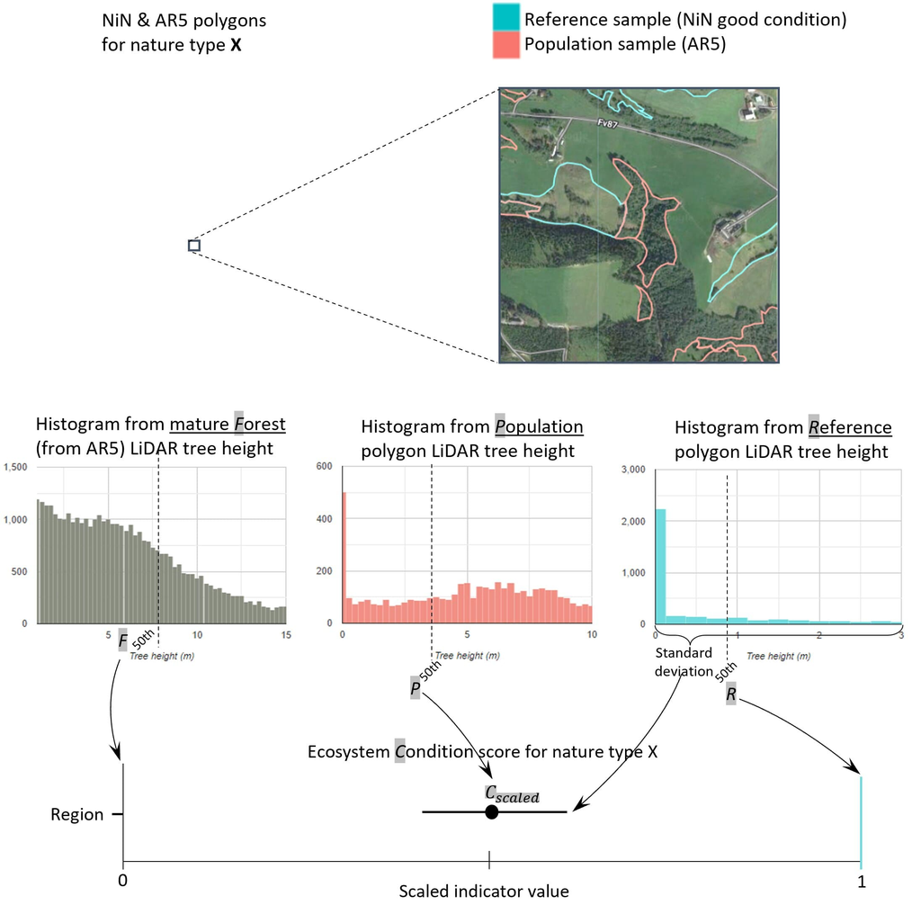

Schematic illustration of how the encroachment indicator is calculated. The lower bound for poor condition is set by LiDAR heights from mature forest surrounding the population polygon. The upper bound for good condition is set by regional median LiDAR heights within NiN polygons in the same bioclimatic-elevation zone as the population polygon.

```
[1] "/data/P-Prosjekter2/412421_okologisk_tilstand_2024/Ida/ecRxiv_gjengroing/indicators/NO_GJEN/R"
```

Once we have the reference vegetation height for a given ecosystem type and elevation-bioclimatic zone, we need to define the minimum (or worst/bad) condition. We use the 50th percentile of LiDAR-derived vegetation heights within AR5 skog polygons to define a climax vegetation successional stage where gjengroing is at its most extreme. In order not to include forest patches that have recently been harvested, we mask out any forest which has been clear-cut since 1986. Here, 1986 is a hard limit defined by the clear-cut dataset which was based on Landsat imagery. Therefore we can be assured that we are measuring forest that is at least 35 years old.

We use both local and regional “reference” approaches to defining poor ecological condition. To do this we calculate the forest heights in AR5 forest patches that fall within 200m of a population polygon (local reference). For population polygons that do not have forest within their proximity, we use the mean forest height within the unique elevation-bioblimatic zone the population falls within (regional reference).

To define the ecological condition of the population polygon, we measure 50th percentile of LiDAR-derived vegetation height. As a reminder, we use AR5 polygons that have types that are approximately compatible with the NiN ecosystem types. For våtmark we use the AR5 polygons defined as “Myr”. For åpne ecosystems we use the AR5 polygons defined as either “Åpent fastmark” or “Innmarksbeite”.

We acknowledge that the AR5 data set has several shortcomings in terms of lags in update frequency and with precision in the maps themselves. This indicator will therefore benefit strongly from new ecosystem delineation maps, that update more frequently, and preferably once that can differentiate between semi-natural and naturally open ecosystems.

The vegetation height percentiles are then scaled to between 0 and 1 using a sigmoid transformation [Oliver at al. (2021)](https://www.sciencedirect.com/science/article/pii/S1470160X21000066).

”

#### 4.2.2. Threshold value for defining *good ecological condition (if relevant)*

#### 4.2.3. Spatial resolution and validity

## 5. Uncertainties

“For the indicator map at the polygon level there is no uncertainty associated with the indicator values. For aggregated indicator values (e.g. for 50km grid and regions), the uncertainty in the indicator value is calculated from the spatial variation in the polygon-level reference height values. We could use the alternative of calculating the spatial variation in the indicator values via bootstrapping using the EAtools package. However, given the extreme number of population polygons, the uncertainty values are extremely small and therefore we choose to use the standard deviation in reference vegetation heights, converted to the indicator scale.”

## 6. References

Links to data and resources are provided with hyperlinks in-line.

## 7. Datasets

“There are several datasets which are used in GEE which will not be imported into the R session here. These datasets have been obtained from the source and ingested into GEE by Zander Venter or Vegar Bakkestuen with the help of Miljødata section at NINA. They include

- [Grunnkart for bruk i arealregnskap](https://nibio.brage.unit.no/nibio-xmlui/handle/11250/3120510)
- [LiDAR-derived digital elevation model from høydedata](https://hoydedata.no/LaserInnsyn/).
- [Kartverket’s national 10m elevation model](https://kartkatalog.geonorge.no/metadata/dtm-10-terrengmodell-utm32/fd851873-f363-46f9-9fc6-bb1b403575df)
- [FKB building footprints](https://kartkatalog.geonorge.no/metadata/fkb-bygning/8b4304ea-4fb0-479c-a24d-fa225e2c6e97)
- [European forest clear-cut map](https://www.nature.com/articles/s41893-020-00609-y)

The remaining datasets will be imported into the R session.

”

### 7.1 Regions

”

The regional delineation for Norway (five regions) are used for aggregating and reporting gjengroing condition values.

```r
regions <- sf::st_read("../data/regions.shp")
# Some issues with the letter "ø"
regions$region[regions$id == 3] <- "Østlandet"
regions$region[regions$id == 5] <- "Sørlandet"

regionlvl <- c("Nord-Norge", "Midt-Norge", "Vestlandet", "Østlandet", "Sørlandet")

regions$region <- factor(regions$region, levels=regionlvl)
```

”

### 7.2 SSB 10 and 50km grids

”

The [SSB 10km and 50km grids](https://kartkatalog.geonorge.no/metadata/statistisk-rutenett-5000m/32ac0653-d95c-446c-8558-bf9b79f4934e) are used for visualizing the distribution of available data and for aggregating gjengroing index scores.

```r
ssb10km <- st_read('/data/R/GeoSpatialData/Population_demography/Norway_SSB/Original/ssb_10km/ssb10km.shp')%>%
  # mutate the id value so that it aligns with the data coming from GEE
  mutate(SSBID = as.numeric(SSBID)/1000)
# Transform to the correct projection
ssb10km <- st_transform(ssb10km, st_crs(regions))

ssb50km <- st_read('/data/R/GeoSpatialData/Population_demography/Norway_SSB/Original/ssb_50km/ssb50km.shp')%>%
  # mutate the id value so that it aligns with the data coming from GEE
  mutate(SSBID = as.numeric(SSBID)/1000)
# Transform to the correct projection
ssb50km <- st_transform(ssb50km, st_crs(regions))
```

”

### 7.3 Bioclimatic regions

The [Moen’s bioclimatic regions](https://data.artsdatabanken.no//Natur_i_Norge/Natursystem/Beskrivelsessystem/Regional_naturvariasjon/Bioklimatisk_sone) are imported from NINA R/GeoSpatialData/ server.

```r
bioclim <- st_read('/data/R/GeoSpatialData/BiogeographicalRegions/Norway_PCA_klima/Converted/Soner2017.shp')
bioclim <- st_transform(bioclim, "EPSG:4326")

# The file is in tiles. Will therefore dissolve these by Sone_navn
bioclim <- bioclim %>%
  group_by(Sone_navn) %>%
  summarise(geometry = st_union(geometry))

# Add unique code for each name called KLASSE
bioclim <- bioclim %>%
  mutate(KLASSE=as.numeric(as.factor(Sone_navn))) %>%
  rename(NAVN="Sone_navn")

vegclimzonelvl <- c("Lavalpin sone (LA)", "Nordboreal sone (NB)", "Mellomboreal sone (MB)", "Sørboreal sone (SB)", "Boreonemoral sone (BN)")

bioclim$NAVN <- factor(bioclim$NAVN, levels=vegclimzonelvl)

# Export the file
if(runFromScratch){
  st_write(bioclim, '../data/bioclimreg.shp', append=FALSE)
}
```

### 7.4 NiN polygons

[NiN polygons](https://kartkatalog.miljodirektoratet.no/dataset/Details/2031) are imported here from the NINA servers:

```r
# Function to extra hovedtype
extract_hovedtype <- function(text) {
  matches <- str_match_all(text, "NA_(.*?)-")
  unique(matches[[1]][, 2])
}

nin <- st_read('/data/R/GeoSpatialData/Habitats_biotopes/Norway_Miljodirektoratet_Naturtyper_nin/Original/Naturtyper - Miljødirektoratets instruks/Naturtyper_nin_0000_norge_25833_FILEGDB.gdb', layer="naturtyper_nin_omr") %>%
  # Fix any invalid geometries
  mutate(validGeo = st_is_valid(SHAPE)) %>%
  filter(validGeo) %>%
  # Simplify ecosystem names
  mutate(hovedøkosystem = recode(hovedøkosystem,
                                 "våtmark" = 'Vaatmark',
                                 "skog" = "Skog",
                                 "fjell" = "Fjell",
                                 "semi-naturligMark" = 'Semi-naturlig',
                                 "naturligÅpneOmråderILavlandet" = 'Naturlig aapne',
                                 "naturligÅpneOmråderUnderSkoggrensa" = 'Naturlig aapne'))
# Transform crs
nin <-st_transform(nin, "EPSG:4326")

# We need to filter out the ecosystems we are not interested in.First, we only include types that are non-alpine by removing the areas that overlap with the bioclimatic zone 'Lavalpin sone (LA)'.
nin <- st_difference(nin, bioclim[bioclim$NAVN == "Lavalpin sone (LA)",])

# Not all alpine types do overlap with this bioclimatic zone due to the resolution of the bioclimatic zone dataset. Thus, we further need to remove these types. In addition, we remove forested wetland types and semi-natural types.
nin <- nin %>%
  filter(!(hovedøkosystem %in% c('Skog','Fjell'))) %>% # Remove forest and alpine ecosystem types
  filter(!(naturtype %in% c('Åpen myrflate i lavalpin sone'))) %>% # Alpine
  filter(!(naturtype %in% c('Hule eiker', # Naturetypes that can have a good condition but has a tree cover >10%
                            'Hagemark',
                            'Lauveng',
                            'Saltpåvirket strand- og sumpskogsmark',
                            'Flommyr, myrkant og myrskogsmark',
                            'Grankildeskog',
                            'Svak kilde og kildeskogsmark',
                            'Sørlig kaldkilde',
                            'Kaldkilde under skoggrensa',
                            'Varmekjær kildelauvskog',
                            'Gammel fattig sumpskog',
                            'Rik gransumpskog',
                            'Rik svartorsumpskog',
                            'Kilde-edellauvskog',
                            'Rik gråorsumpskog',
                            'Kalkrik myr- og sumpskogsmark',
                            'Rik vierstrandskog',
                            'Rik svartorstrandskog',
                            'Saltpåvirket svartorstrandskog',
                            'Leirravine' # This type is often not open
                            ))) %>%
  # Get the main ecosystem codes. As there are multiple types in a column, we need to use a function (see above)
  mutate(hovedtype = sapply(ninKartleggingsenheter, function(x) paste(extract_hovedtype(x), collapse = ",")),
         id = identifikasjon_lokalId) %>%
  # Drop polygons with no condition score
  drop_na(tilstand) %>%
  # Only included specific columns
  dplyr::select(id, hovedøkosystem, hovedtype, naturtypeKode, tilstand)
```

- **Export the cleaned NiN data and upload to GEE before proceeding**

```r
# Only run if you are repeating this workflow for the first time
if(runFromScratch){
nin %>%
   dplyr::select(id, hovedøkosystem, tilstand) %>%
   st_transform("EPSG:4326") %>%
   st_write('../data/nin_cleaned.shp', append=FALSE)
}
```

- **Now run the following GEE JavaScript code by clicking on the hyperlink:** [GEE script](https://code.earthengine.google.com/25736c6d4f73298e30283ce9b41ab240) (updated script). This script is also found in the SCR repository as “GEE_script.js”. When you run the script, then click the Tasks tab in the GEE code editor and run the export tasks. The export files will appear in your Google Drive. Download the files from your Google Drive to the /data/gjengroing/From_GEE directory. This script extracts three CSV files:
  - ‘area_cover_grid.csv’ - this gives the area coverage of NiN, AR5 and LiDAR data for each 10x10km SSB grid cell.
  - ‘elevation_stratified.shp’ - this is a 300m elevation band stratification that is simply used for visualizing the strata here in R.
  - ‘vegHeights.zip’ - this is a folder with hundreds of CSV files. These files contain the vegetation heights for reference, population, and forest polygons over Norway. The exports were split by 50km grid to prevent hitting user memory limits in GEE. Unzip the folder before you upload to ./DATA/From_GEE/

### 7.5 Data from Google Earth Engine

Once you have run the GEE script above, and downloaded the data to the `/From_GEE/` directory, you can proceed with this R workflow.

Create functions to import vegetation height files and stratify data by bioclimatic zone and region.

```r
# Function to read in multiple files resulting from GEE exports
readVegHeightFiles <- function(uniqueString){
  dir <- '/data/P-Prosjekter2/412421_okologisk_tilstand_2024/Ida/From_GEE/vegHeights/'
  files <- list.files(dir)[str_detect(list.files(dir), uniqueString)]
  #print(files)

  dat <- tibble()
  for (i in files){
    dat <- dat %>%
      bind_rows(read_csv(paste0(dir, i)) %>%
                  mutate(ssbid = substr(str_split(i, '_')[[1]][3], 1, 14)))
  }
  return (dat)
}

# Vegetation type lookup
vegLookup <- tibble(
  vegClimZone = c(1,2,3,4,5),
  vegClimZoneLab = c('Boreonemoral sone (BN)','Lavalpin sone (LA)','Mellomboreal sone (MB)','Nordboreal sone (NB)','Sørboreal sone (SB)')
  )

# Bioclimatic zone and region cleaning function
cleanRegClim <- function(data){

  dataOut <- data %>%
    mutate(region=ifelse(region_id == 1, 'Nord-Norge',
                         ifelse(region_id == 2, 'Midt-Norge',
                                ifelse(region_id == 3, 'Østlandet',
                                       ifelse(region_id == 4, 'Vestlandet', 'Sørlandet'))))) %>%

    mutate(vegClimZone = round(vegClimZone)) %>%
    left_join(vegLookup, by = 'vegClimZone') %>%
    dplyr::select(-region_id, -vegClimZone) %>%
    drop_na(vegClimZoneLab, region)

  return (dataOut)

}
```

Import the CSV files generated in GEE related to area covers and regions

```r
# Import data coverages per SSB 10km grid cell
areaCovers <- read_csv('/data/P-Prosjekter2/412421_okologisk_tilstand_2024/Ida/From_GEE/area_cover_grid.csv') %>%
  dplyr::select(-'.geo', -'system:index')

# Calculate percentage cover relative to the land area in each cell
areaCoversPerc <- areaCovers %>%
  gather(key, val, vaatmark_pop, aapne_pop, semi_pop, vaatmark_nin, aapne_nin, semi_nin, lidarCover, skog) %>%
  mutate(type = ifelse(str_detect(key, 'pop'), 'pop',
                       ifelse(str_detect(key, 'nin'), 'nin',
                              ifelse(key == 'lidarCover', 'lidar', NA)))) %>%
  mutate(ecosystem = ifelse(str_detect(key, 'aapne'), 'Naturlig åpne',
                       ifelse(str_detect(key, 'vaatmark'), 'Våtmark',
                              ifelse(str_detect(key, 'semi'), 'Semi-naturlig',NA)))) %>%
  mutate(areaPerc = val/land*100,
         areaPerc = ifelse(is.na(areaPerc), 0, areaPerc)) %>%
  dplyr::select(SSBID, key, type,ecosystem, areaPerc)
```

Import forest heights per region bioclimatic zone combination.

```r
skog_region_bioclim <- read_csv("/data/P-Prosjekter2/412421_okologisk_tilstand_2024/Ida/From_GEE/vegHeights_skog_climZoneRegion.csv")

names(skog_region_bioclim)[2:4] <- c("vegClimZone","skog","region_id")

skog_region_bioclim <- skog_region_bioclim %>%
  dplyr::select(-c('system:index','.geo'))
```

If not already done manually, extract files from the zipped GEE folder.

```r
zipped_folder <- list.files("/data/P-Prosjekter2/412421_okologisk_tilstand_2024/Ida/From_GEE/",
                            pattern=".zip$",full.names=T)
unzipped_folder <- "/data/P-Prosjekter2/412421_okologisk_tilstand_2024/Ida/From_GEE"

unzip(zipped_folder,exdir=unzipped_folder)
```

Import the CSV files generated in GEE of vegetation heights (circa 15 min runtime):

```r
ecosysttypes <- c("vaatmark", "aapne", "semi")


for(i in 1:length(ecosysttypes)){

    ecosysttype <- ecosysttypes[i]

    # Import median LiDAR heights for NiN polygons
    refecosysttypeRaw <- readVegHeightFiles(paste0(ecosysttype,'_ref')) %>%
    mutate(ref = chm) %>%
    dplyr::select(-'.geo', -'system:index', -chm)

    # Add region and bioclim zones and summarise per strata
    # this will form the upper limit of the ecological condition score (ie. good condition)
  refecosysttype <- cleanRegClim(refecosysttypeRaw) %>%
    group_by(region, vegClimZoneLab) %>%
    summarise(ref = median(ref, na.rm=T))

  # Export to file for reference
  refecosysttype %>%
    st_write(paste0('../data/ref',ecosysttype,'.csv'), append=FALSE)

  # Import median LiDAR heights for GFA polygons for population measurement
  popecosysttypeHt <- readVegHeightFiles(paste0(ecosysttype,'_pop'))  %>%
    mutate(pop = chm)%>%
    dplyr::select(-chm)

  # Turn into spatial objects using the .geo column in the CSV
  popecosysttypeHt <- st_as_sf(bind_cols(popecosysttypeHt,geojsonsf::geojson_sf(popecosysttypeHt$.geo)))

  # Combine median LiDAR heights for forest per region and bioclimatic zone combination with population heights.
  # This will form the lower limit of the ecological condition score (ie. poor condition)
  popecosysttype <- popecosysttypeHt %>%
    left_join(skog_region_bioclim, by = c('vegClimZone','region_id'))

  # Add region and bioclimatic zone names to the combined population and forest heights
  popecosysttype <- cleanRegClim(popecosysttype)
  assign(paste0('pop',ecosysttype), popecosysttype)

  # Combine all the above into one data frame
  set.seed(123)
  ecosysttypeHts <- popecosysttype %>%
    #sample_n(100000) %>%
    as_tibble() %>% dplyr::select(-geometry) %>%
    left_join(refecosysttype, by=c('vegClimZoneLab', 'region')) %>%
    gather(type, height, ref, pop, skog) %>%
    group_by(`system:index`, region, vegClimZoneLab, type) %>%
    summarise(height = mean(height)) %>%
    pivot_wider(values_from = height, names_from = type) %>%
    # If population height is less than the reference value, then it is automatically "good" condition - ie. it inherits the reference height so that the rescaled value will be 1
    mutate(pop = ifelse(pop < ref, ref, pop)) %>%
    drop_na(pop, ref) %>%
    #left_join(ecosysttypeSkogRegionalRef, by = c('vegClimZoneLab', 'region')) %>%
    #mutate(skog = ifelse(is.na(skog), skogFill, skog)) %>%
    #dplyr::select(-skogFill) %>%
    filter(skog < 30)
  #colSums(is.na(ecosysttypeHts))

  assign(paste0(ecosysttype,"Hts"), ecosysttypeHts)

  st_write(ecosysttypeHts, paste0('../data/', ecosysttype,'hts.csv'), append=FALSE)

 }
```

```
Deleting layer `refvaatmark' using driver `CSV'
Writing layer `refvaatmark' to data source
  `../data/refvaatmark.csv' using driver `CSV'
Updating existing layer refvaatmark
Writing 19 features with 3 fields without geometries.
Deleting layer `vaatmarkhts' using driver `CSV'
Writing layer `vaatmarkhts' to data source
  `../data/vaatmarkhts.csv' using driver `CSV'
Updating existing layer vaatmarkhts
Writing 612980 features with 6 fields without geometries.
Deleting layer `refaapne' using driver `CSV'
Writing layer `refaapne' to data source `../data/refaapne.csv' using driver `CSV'
Updating existing layer refaapne
Writing 18 features with 3 fields without geometries.
Deleting layer `aapnehts' using driver `CSV'
Writing layer `aapnehts' to data source `../data/aapnehts.csv' using driver `CSV'
Updating existing layer aapnehts
Writing 273 features with 6 fields without geometries.
Deleting layer `refsemi' using driver `CSV'
Writing layer `refsemi' to data source `../data/refsemi.csv' using driver `CSV'
Updating existing layer refsemi
Writing 20 features with 3 fields without geometries.
Deleting layer `semihts' using driver `CSV'
Writing layer `semihts' to data source `../data/semihts.csv' using driver `CSV'
Updating existing layer semihts
Writing 332 features with 6 fields without geometries.
```

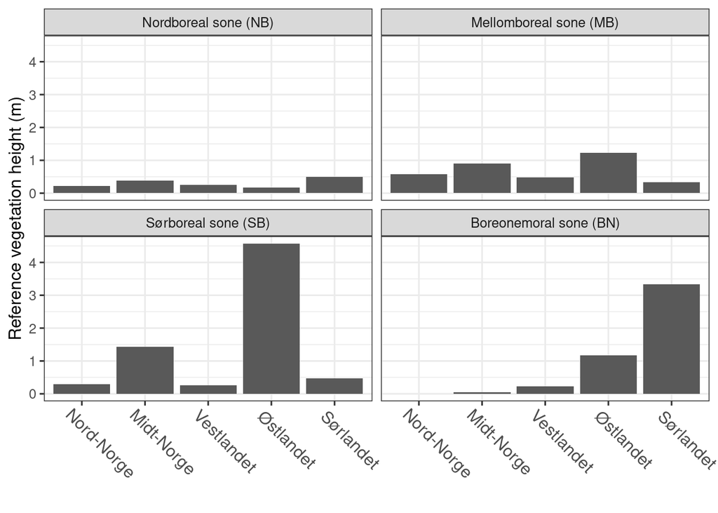

Reference vegetation height in wetland ecosystems under the forest line in Norway.

```r
refvaatmark  <- read_csv('../data/refvaatmark.csv')

refvaatmark$region <- factor(refvaatmark$region, levels=regionlvl)
refvaatmark$vegClimZoneLab <- factor(refvaatmark$vegClimZoneLab, levels=vegclimzonelvl)

refvaatmark %>%
  ggplot(aes(x = region, y = ref))+
  geom_bar(stat="identity")+
  theme_bw(base_size = 12)+
  theme(axis.text.x = element_text(angle = -45, vjust = 0.5, hjust = 0.2, size = 12))+
  facet_wrap(.~vegClimZoneLab)+
  labs(y = "Reference vegetation height (m)",
       x = " ")
```

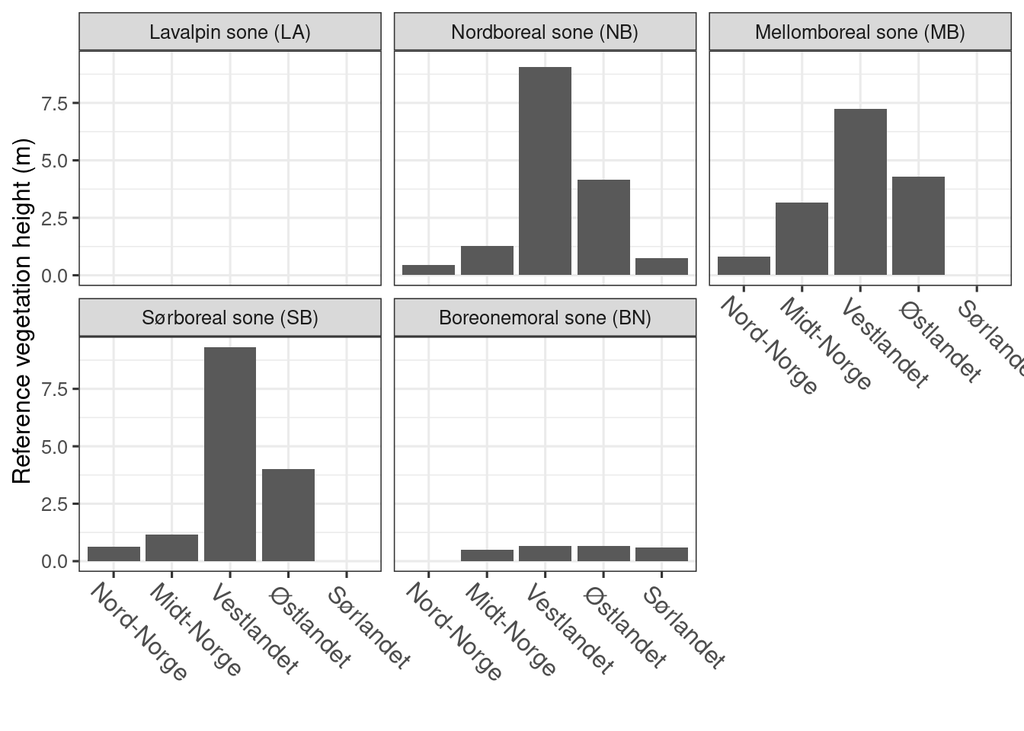

Reference vegetation height in natural open ecosystems under the forest line in Norway.

```r
refaapne <- read_csv('../data/refaapne.csv')

refaapne$region <- factor(refaapne$region, levels=regionlvl)
refaapne$vegClimZoneLab <- factor(refaapne$vegClimZoneLab, levels=vegclimzonelvl)

refaapne %>%
  ggplot(aes(x = region, y = ref))+
  geom_bar(stat="identity")+
  theme_bw(base_size = 12)+
  theme(axis.text.x = element_text(angle = -45, vjust = 0.5, hjust = 0.2, size = 12))+
  facet_wrap(.~vegClimZoneLab)+
  labs(y = "Reference vegetation height (m)",
       x = "")
```

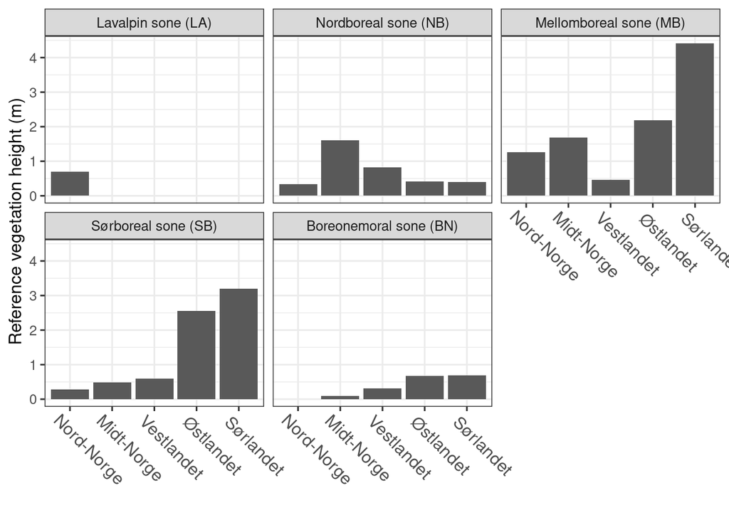

Reference vegetation height in semi-natural ecosystems under the forest line in Norway.

```r
refsemi <- read_csv('../data/refsemi.csv')

refsemi$region <- factor(refsemi$region, levels=regionlvl)
refsemi$vegClimZoneLab <- factor(refsemi$vegClimZoneLab, levels=vegclimzonelvl)

refsemi %>%
  ggplot(aes(x = region, y = ref))+
  geom_bar(stat="identity")+
  theme_bw(base_size = 12)+
  theme(axis.text.x = element_text(angle = -45, vjust = 0.5, hjust = 0.2, size = 12))+
  facet_wrap(.~vegClimZoneLab)+
  labs(y = "Reference vegetation height (m)",
       x = " ")
```

## 8. Spatial units

## 9. Analyses

We will calculate the gjengroing index for each population polygon over Norway using a Sigmoid scaling function.

```r
# Define Sigmoid scaling function
scaleSigmoid <- function(variable){
  refLow <- min(variable)
  refHigh <- max(variable)
  thr <- (refHigh-refLow)/2
  indicator_LowHigh <- (variable - refLow)/(refHigh - refLow)
  indicator_LowHigh[indicator_LowHigh[] < 0] <- 0
  indicator_LowHigh[indicator_LowHigh[] > 1] <- 1
  indicator_sigmoid <- 100.68*(1-exp(-5*(indicator_LowHigh)^2.5))/100
  return (round(indicator_sigmoid, 4))
}
```

### 9.1 Subset population data

An initial test (not shown here) was done for natural open and semi-natural polygons but the enchroachment index did not change depending on number of samples. Thus, we will only subset the wetland population data.

To decide on the number of polygons to use per gridcell, we will calculate the enchroachment index with n number of polygons to get a stable estimate.

```r
ecosysttypes <- c("wetland", "aapne", "semi")

    popecosysttype <- get(paste0('pop',ecosysttype))
  #nrsamples <- unique(round(seq(10, nrow(popecosysttype), length.out=20))) # Proportions to sample
    propsamples <- seq(0.025,1,0.05)

    ecosysttypeHts0 <- get(paste0(ecosysttype,'Hts'))
    ecosysttypeHts0 <- ecosysttypeHts0 %>%
        left_join(popecosysttype %>% dplyr::select("system:index", ssbid))


for(i in 1:1){ #for(i in 1:length(ecosysttypes)){

    # Nr of samples
    ecosysttype <- ecosysttypes[i]
    popecosysttype <- get(paste0('pop',ecosysttype))

    indexGrids <- data.frame(ssbid=ecosysttypeHts0$ssbid)


    for(n in 1:length(propsamples)){
      print(propsamples[n])

      # Sample n population polygons
      set.seed(123)
      ecosysttypeHts <- ecosysttypeHts0 %>%
        group_by(ssbid) %>%
        sample_frac(size=propsamples[n]) #sample_n

      # Calculate gjengroing index values
  ecosysttypeIndexPoly <- ecosysttypeHts  %>%
    # Gather into long format so that we can mutate the scaleSigmoid() function
    gather(type, height, ref, pop, skog) %>%
    group_by(`system:index`) %>%
    mutate(index = scaleSigmoid(height)) %>%
    # Because short vegetation is good condition, we must invert the scaled indicator
    mutate(index = 1-index) %>%
    # Get the indicator values for the population polygons only (ref and skog will be 1 and 0)
    filter(type == 'pop') %>%
    dplyr::select(-type, -height) %>%
    # Join with original data to get the actual median vegetation heights for each indicator score
    left_join(ecosysttypeHts %>% dplyr::select("system:index", pop, ref, skog))

  # Calculate mean and sd index value per gridcell and save for later
        indexGrid <- ecosysttypeIndexPoly %>%
        group_by(ssbid) %>%
        summarise(meangrid=mean(index))

        names(indexGrid)[2] <- paste0(names(indexGrid)[2], propsamples[n])

        indexGrids <- indexGrids %>%
          left_join(indexGrid)

    }

    indexGridsT <- data.frame(t(indexGrids))
    names(indexGridsT) <- indexGridsT[1,]
    indexGridsT <- indexGridsT[-1,]
    indexGridsT$nrsamples <- as.numeric(substr(row.names(indexGridsT),9, nchar(row.names(indexGridsT))))
    names(indexGridsT) <- paste0("c",names(indexGridsT))

    #require(data.table)
    indexGridsLong <- melt(setDT(indexGridsT), id.vars = "cnrsamples", variable.name = "ssbid")
    indexGridsLong$value <- as.numeric(indexGridsLong$value)


    ggplot(indexGridsLong, aes(cnrsamples,value)) +
      #geom_point()
      stat_smooth(method='lm', formula = y~poly(x,2))
      #geom_smooth()

}
```

### 9.2 Scaled indicator values at polygon level (circa **120** min runtime)

```r
ecosysttypes <- c("vaatmark", "aapne", "semi")

for(i in 1:length(ecosysttypes)){

    ecosysttype <- ecosysttypes[i]

    ecosysttypeHts <- get(paste0(ecosysttype,'Hts'))
    popecosysttype <- get(paste0('pop',ecosysttype))


  # Calcualte gjengroing index values
  ecosysttypeIndexPoly <- ecosysttypeHts  %>%
    # Gather into long format so that we can mutate the scaleSigmoid() function
    gather(type, height, ref, pop, skog) %>%
    group_by(`system:index`) %>%
    mutate(index = scaleSigmoid(height)) %>%
    # Because short vegetation is good condition, we must invert the scaled indicator
    mutate(index = 1-index) %>%
    # Get the indicator values for the population polygons only (ref and skog will be 1 and 0)
    filter(type == 'pop') %>%
    dplyr::select(-type, -height) %>%
    # Join with original data to get the actual median vegetation heights for each indicator score
    left_join(ecosysttypeHts %>% dplyr::select("system:index", pop, ref, skog)) %>%
    left_join(popecosysttype %>% dplyr::select("system:index", ssbid))

  # Make into spatial objects
  ecosysttypeIndexPolySpat <- popecosysttype %>%
    dplyr::select("system:index") %>%
    left_join(ecosysttypeIndexPoly) %>%
    filter(!is.na(index)) %>%
    # Transform to correct projection
    st_transform(st_crs(regions))

  assign(paste0(ecosysttype,"IndexPolySpat"), ecosysttypeIndexPolySpat)

}
```

```r
# Create intersection of the two strata layers
bioclim <- st_transform(bioclim, st_crs(regions))
bioClimReg <- bioclim %>%
  st_intersection(regions) %>%
    mutate(vegClimZoneLab = NAVN) %>%
    dplyr::select(region, vegClimZoneLab) %>%
  rowid_to_column("ID")

ecosysttypes <- c("vaatmark", "aapne", "semi")

for(i in 1:length(ecosysttypes)){
    ecosysttype <- ecosysttypes[i]

    if(runFromScratch){
      ecosysttypeIndexPolySpat <- get(paste0(ecosysttype, "IndexPolySpat"))
            # Get area-weighted mean for reference, forest and population vegetation heights
      # for each unique bioclimatic zone-region combination
      ecosysttypeIndexStrata <- bioClimReg %>%
        #sample_n(10000) %>%
        st_join(ecosysttypeIndexPolySpat %>%
                    mutate(area = as.numeric(st_area(geometry))) ,st_intersects) %>%
        group_by(ID) %>%
        summarise_at(vars(pop, ref, skog, index), funs(weighted.mean(., w=area, na.rm=TRUE)))%>%
        as_tibble() %>%
        dplyr::select(-geometry)

       # Write out for import later
      ecosysttypeIndexStrata %>% write_csv(paste0('../data/',ecosysttype,'IndexStrata.csv'))

      assign(paste0(ecosysttype, "IndexStrata"),ecosysttypeIndexStrata)

    }
}
```

### 9.3 Scaled indicator values at 50km grid level (circa 45 min runtime)

“Using the polygon-level indicator scores, we will aggregate to 50km grid level to explore the spatial variation over Norway. We are doing this as an alternative way of visualizing the broad-scale patterns as presented in the section above where we used bioclimatic-elevation strata.

Here we will use a weighted average, but test out the eaTools::ea_spread function! It takes some time to run so best to do this overnight, or to parallelize in some way.”

```r
ecosysttypes <- c("vaatmark", "aapne", "semi")

for(i in 1:length(ecosysttypes)){

    ecosysttype <- ecosysttypes[i]

    if (runFromScratch){

    ecosysttypeIndexPolySpat <- get(paste0(ecosysttype,'IndexPolySpat'))

    # Aggregate polygon index scores to grid level using eaTools ea_spread function
    ecosysttypeIndexGrid <- eaTools::ea_spread(indicator_data = ecosysttypeIndexPolySpat,
                                            indicator = index,
                                            regions = ssb50km,
                                            groups = SSBID,
                                            threshold = 1) %>%
    mutate(index = w_mean, ssbid = ID) %>%
    dplyr::select(ssbid, index, sd)

    # Export
    ecosysttypeIndexGrid %>% st_write(paste0('../data/',ecosysttype,'_index_grid.shp'))

    assign(paste0(ecosysttype, "IndexGrid"),ecosysttypeIndexGrid)

    }

}
```

### 9.4 Scaled indicator values at regional level (circa 120 min runtime)

“Now we will aggregate up to the regional level for final reporting. We will use the same method as in the section above, except here we will use a different method to calculate the uncertainty value around the indicator values. The ea_spread function in eaTools uses a bootstrapping method to calculate the standard error in indicator values when aggregating from the polygon to regional level. Because we have hundreds of thousands of polygons per region, the resulting standard errors are extremely small. Therefore we will use the standard deviation in reference values per region. The standard deviation, as a percentage of the average reference value is used to calculate the uncertainty in the scaled indicator value.”

```r
ecosysttypes <- c("vaatmark", "aapne","semi")

for(i in 1:length(ecosysttypes)) {

      ecosysttype <- ecosysttypes[i]

      if (runFromScratch){

      # Get the mean population, reference and forest heights per region for interpreting index values
      # The standard deviation is used later to define uncertainty around the indicator score
      ecosysttypeIndexPolySpat <- get(paste0(ecosysttype, "IndexPolySpat"))


      ecosysttypeHeightsRegion <- regions %>%
        st_join(ecosysttypeIndexPolySpat) %>%
        as_tibble() %>%
        drop_na(index) %>%
        # Some errors in column names on the way but region.x and region.y are the same
        mutate(region=region.x) %>%
        dplyr::select(-region.x, -region.y) %>%
        group_by(region) %>%
        summarise(pop_mean = mean(pop),
                  skog_mean = mean(skog),
                  ref_mean = mean(ref),
                  sd_ref = sd(ref))

     # Aggregate polygon index scores to regional level using eaTools
      ecosysttypeIndexRegion <- eaTools::ea_spread(indicator_data = ecosysttypeIndexPolySpat,
                                              indicator = index,
                                              regions = regions,
                                              groups = region,
                                              threshold = 1) %>%
      mutate(index = w_mean, region = ID) %>%
      dplyr::select(region, index, sd) %>%
      left_join(ecosysttypeHeightsRegion)

      ecosysttypeIndexRegion %>% st_write(paste0('../data/',ecosysttype,'_index_grid.shp'), append=F)

      assign(paste0(ecosysttype, "IndexRegion"),ecosysttypeIndexRegion)

  }
}
```

### 9.4 Validation

Run test on an independent subset of data.

”

The calculation of the indicator involves many small decisions which can have significant effects on the resulting conditions cores. Therefore in the future it would be good to perform sensitivity analyses with each decision to test the effect on the outcome. The decisions which would benefit from further exploration include:

- **Selection of the reference and population areas.** Here we were limited to using NiN and AR5 because these are arguably the best datasets currently available for this exercise. However, both NiN and AR5 are spatially and thematically biased in some ways. Therefore, it may be worth exploring alternative datasets in the future. NiN polygons are biased towards low lying areas which are generally warmer and more productive. For a given bioclimatic-elevation strata, this could lead to higher reference values for vegetation height than one would expect with a representative reference sample. This could consequently result in high elevation population polygons appearing to have very good condition because they are being compared with (relatively) high productivity polygons in the same bioclimatic-elevation strata. This is a possible explanation for why the high elevation parts of Norway appear to be in very good ecological condition.
- **Definition of good condition states in NiN data.** Here we used the overall “tilstand” score for each NiN reference polygon. However, the overall score is a combination of several sub-scores that may or may not be relevant for ecological condition. For instance, ditches or wheel marks in wetlands is a common condition score in NiN, however it is debatable as to whether this should be considered a part of ecological condition. Therefore it may be beneficial to attempt repeating the indicator calculation using sub-categories of “tilstand” in the NiN data.
- **Definition of climax successional stage for tree regrowth.** Here we use the 50th percentile of LiDAR-derived tree heights in AR5 forest polygons that have not been harvested since 1986. This defines the zero on the scaled indicator score. The resulting indicator scores will vary widely depending on how you define this zero-point. Therefore, testing different definitions (i.e. tree height percentiles) may be important.
- **Quantifying regional vs local references for poor and good condition.** For good condition, we used NiN polygons and were restricted to these due to lack of better data. However, for poor condition we use climax successional stage for trees (as explained above) within 200m of each population polygon. For polygons with no surrounding forest, we impute with regional reference values (mean of forest height in elevation-bioclamic zone). The choice of 200m buffer zone was largely based on computational limitations. Calculating the average LiDAR vegetation height within 200m of nearly 2 million complex polygons takes time, even in GEE. It may make more ecological sense to define a larger buffer zone to use for defining reference for poor condition. However, longer processing times need to be expected.
- **Quantification of uncertainty around indicator scores.** Here we used the standard deviation in the vegetation heights for reference (NiN) polygons within each region to quantify the uncertainty around scaled indicator scores. We did this because the method used in `eaTools::ea_spread()` function is a bootstrapping approach which resulted in extremely small uncertainty estimates due to the large number of polygons included in our analysis. [In the future, a better method for quantifying uncertainty is needed.](https://github.com/NINAnor/eaTools/issues/17) Perhaps by running sensitivity analyses that test several variations of the points mentioned above can form the basis for quantifying an error margin around indicator values.

”

## 10. Results

### 10.1 Scaled indicator values at polygon level

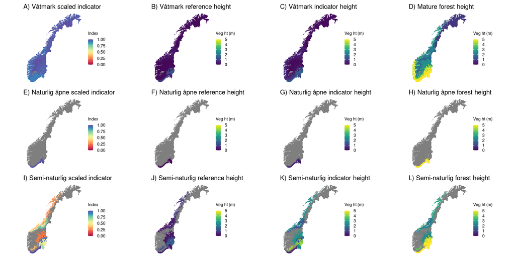

Maps of scaled and unscaled indicator values, as well as reference values. For the unscaled variables the legend is truncated at 5 m to ensure the same colour gradient for all maps.

```r
# Import datasets
ecosysttypes <- c("vaatmark", "aapne", "semi")

for(i in 1:length(ecosysttypes)){
    ecosysttype <- ecosysttypes[i]

    ecosysttypeIndexStrata <- read_csv(paste0('../data/',ecosysttype,'IndexStrata.csv'))

    assign(paste0(ecosysttype, "IndexStrata"),ecosysttypeIndexStrata)
}


# Make plots of indicator heights and scaled condition values for each strata polygon

theme_legend_1 <- theme(legend.key.size = unit(0.25, 'cm'), #change legend key size
                        legend.key.height = unit(0.25, 'cm'), #change legend key height
                        legend.key.width = unit(0.25, 'cm'), #change legend key width
                        legend.title = element_text(size=6), #change legend title font size
                        legend.text = element_text(size=6)) #change legend text font size

makeStrataHeightMap <- function(data, var, title, limits){
  p <- bioClimReg %>%
    left_join(data, by = c('ID'))  %>%
    mutate(response = .[[var]]) %>%
    ggplot() +
    geom_sf(aes(fill = response), color=NA)+
      scale_fill_gradientn(colors=viridis::viridis(10),
                           limits = limits,
                           oob = scales::squish,
                           name = 'Veg ht (m)')+
      ggtitle(title) +
      theme_void() +
    theme(plot.title = element_text(size=9)) +
    theme_legend_1

  return (p)
}

makeStrataIndicatorMap <- function(data, title){
  p <- bioClimReg %>%
    left_join(data, by = c('ID'))  %>%
    ggplot() +
    geom_sf(aes(fill = index), color=NA)+
      scale_fill_gradientn(colors=brewer.pal(10, 'Spectral'),
                           limits = c(0,1),
                           name = 'Index')+
      ggtitle(title) +
      theme_void()+
    theme(plot.title = element_text(size=9)) +
    theme_legend_1

  return (p)
}

v1 <- makeStrataIndicatorMap(vaatmarkIndexStrata, 'A) Våtmark scaled indicator')
v2 <- makeStrataHeightMap(vaatmarkIndexStrata, "ref", 'B) Våtmark reference height', c(0,5))
v3 <- makeStrataHeightMap(vaatmarkIndexStrata, "pop", 'C) Våtmark indicator height', c(0,5))
v4 <- makeStrataHeightMap(vaatmarkIndexStrata, "skog", 'D) Mature forest height', c(0,5))

a1 <- makeStrataIndicatorMap(aapneIndexStrata,  'E) Naturlig åpne scaled indicator')
a2 <- makeStrataHeightMap(aapneIndexStrata, "ref", 'F) Naturlig åpne reference height', c(0,5))
a3 <- makeStrataHeightMap(aapneIndexStrata, "pop", 'G) Naturlig åpne indicator height', c(0,5))
a4 <- makeStrataHeightMap(aapneIndexStrata, "skog", 'H) Naturlig åpne forest height', c(0,5))

s1 <- makeStrataIndicatorMap(semiIndexStrata,  'I) Semi-naturlig scaled indicator')
s2 <- makeStrataHeightMap(semiIndexStrata, "ref", 'J) Semi-naturlig reference height', c(0,5))
s3 <- makeStrataHeightMap(semiIndexStrata, "pop", 'K) Semi-naturlig indicator height', c(0,5))
s4 <- makeStrataHeightMap(semiIndexStrata, "skog", 'L) Semi-naturlig forest height', c(0,5))


strataHeightPlot <- grid.arrange(v1,v2,v3,v4,
                                 a1,a2,a3,a4,
                                 s1,s2,s3,s4,
                                 ncol=4, widths=c(1,1,1,1), padding = unit(0, "line"), newpage = T)
```

```r
print('Will import pre-exported data')
```

```
[1] "Will import pre-exported data"
```

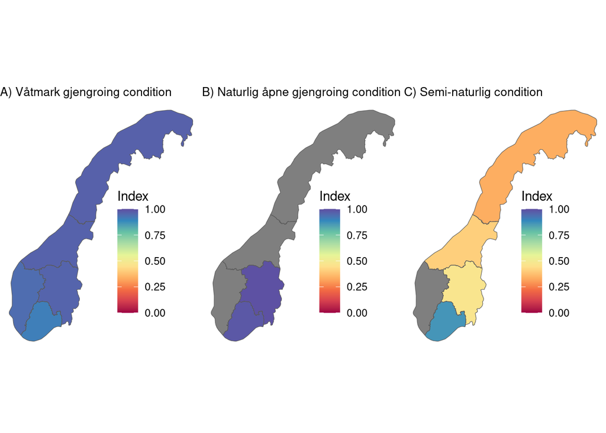

```r
ecosysttypes <- c("vaatmark", "aapne", "semi")

for(i in 1:length(ecosysttypes)){

    ecosysttype <- ecosysttypes[i]

    ecosysttypeIndexGrid <- st_read(paste0('../data/',ecosysttype,'_index_grid.shp'))

    assign(paste0(ecosysttype, "IndexGrid"),ecosysttypeIndexGrid)

}
vGrid1 <- vaatmarkIndexGrid %>%
  ggplot() +
  geom_sf(aes(fill=index), color=NA) +
  geom_sf(data=regions, fill=NA, size=0.5) +
  scale_fill_gradientn(colors=brewer.pal(10, 'Spectral'),
                       limits = c(0,1),
                       name = 'Index') +
  theme_void() +
  theme(legend.position = c(0.7, 0.4),
        plot.title = element_text(size=10)) +
  ggtitle('A) Våtmark gjengroing condition')

vGrid2 <- aapneIndexGrid %>%
  ggplot() +
  geom_sf(aes(fill=index), color=NA) +
  geom_sf(data=regions, fill=NA, size=0.5) +
  scale_fill_gradientn(colors=brewer.pal(10, 'Spectral'),
                       limits = c(0,1),
                       name = 'Index') +
  theme_void() +
  theme(legend.position = c(0.7, 0.4),
        plot.title = element_text(size=10)) +
  ggtitle('B) Naturlig åpne gjengroing condition')

vGrid3 <- semiIndexGrid %>%
  ggplot() +
  geom_sf(aes(fill=index), color=NA) +
  geom_sf(data=regions, fill=NA, size=0.5) +
  scale_fill_gradientn(colors=brewer.pal(10, 'Spectral'),
                       limits = c(0,1),
                       name = 'Index') +
  theme_void() +
  theme(legend.position = c(0.7, 0.4),
        plot.title = element_text(size=10)) +
  ggtitle('C) Semi-naturlig condition')



indexGridFig <- grid.arrange(vGrid1, vGrid2, vGrid3, ncol=3, widths=c(1,1,1),
                             padding = unit(0, "line"), newpage = T)
```

### 10.3 Scaled indicator values at regional level

Present the indicator values as table, plots, and maps:

```r
print('Will import pre-exported data')
```

```
[1] "Will import pre-exported data"
```

```r
ecosysttypes <- c("vaatmark", "aapne","semi")

for(i in 1:length(ecosysttypes)) {

      ecosysttype <- ecosysttypes[i]

      ecosysttypeIndexRegion <- st_read(paste0('../data/',ecosysttype,'_index_grid.shp'))

      assign(paste0(ecosysttype, "IndexRegion"),ecosysttypeIndexRegion)
}
# Join into a table to present values
vaatmarkTable <- vaatmarkIndexRegion %>% as_tibble()
aapneTable <- aapneIndexRegion %>% as_tibble()
semiTable <- semiIndexRegion %>% as_tibble()

aapneTable %>% mutate(Ecosystem = 'Naturlig åpne')
```

```
# A tibble: 5 × 9
  region      index       sd pop_mean skog_mean ref_mean sd_ref
  <chr>       <dbl>    <dbl>    <dbl>     <dbl>    <dbl>  <dbl>
1 Nord-Norge NA     NA         NA         NA     NA          NA
2 Midt-Norge NA     NA         NA         NA     NA          NA
3 Østlandet   0.996  0          0.446      6.37   0.0930     NA
4 Vestlandet NA     NA         NA         NA     NA          NA
5 Sørlandet   0.984  0.00738    0.650      5.75   0.217       0
# ℹ 2 more variables: geometry <POLYGON [m]>, Ecosystem <chr>
```

```r
# Join ecosystem types and calculate uncertainty
indicatorTable <- vaatmarkTable %>% mutate(Ecosystem = 'Våtmark') %>%
  bind_rows(aapneTable %>% mutate(Ecosystem = 'Naturlig åpne')) %>%
  bind_rows(semiTable %>% mutate(Ecosystem = 'Semi-naturlig')) %>%

  # Calculate the error based on the standard deviation in reference polygon heights
  # as a percentage of the reference height, and multiply by index score
  mutate(sd = (sd_ref/ref_mean)*index)

# Format the table for presentation
indicatorTable_formatted <- regions %>%
  left_join(indicatorTable) %>% as_tibble() %>%
  dplyr::select(-geometry)  %>%
  dplyr::select( region, Ecosystem, index, sd, pop_mean, ref_mean, skog_mean) %>%
  mutate_if(is.numeric, round, 2)
names(indicatorTable_formatted) <- c( "Region", "Ecosystem",
                                      "Scaled indicator",  "Scaled Std.dev",
                                      "Indicator height","Reference height",
                                      "Mature forest height")

# Use knitr to visualize
knitr::kable(indicatorTable_formatted)
```

| Region | Ecosystem | Scaled indicator | Scaled Std.dev | Indicator height | Reference height | Mature forest height |
| --- | --- | --- | --- | --- | --- | --- |
| Nord-Norge | Våtmark | 0.97 | 0.07 | 0.40 | 0.11 | 1.49 |
| Nord-Norge | Naturlig åpne | NA | NA | NA | NA | NA |
| Nord-Norge | Semi-naturlig | 0.33 | 0.09 | 1.89 | 0.68 | 2.92 |
| Midt-Norge | Våtmark | 0.96 | 0.38 | 0.81 | 0.26 | 2.17 |
| Midt-Norge | Naturlig åpne | NA | NA | NA | NA | NA |
| Midt-Norge | Semi-naturlig | 0.41 | 0.14 | 2.49 | 0.30 | 2.02 |
| Østlandet | Våtmark | 0.96 | 1.35 | 1.43 | 0.37 | 4.63 |
| Østlandet | Naturlig åpne | 1.00 | NA | 0.45 | 0.09 | 6.37 |
| Østlandet | Semi-naturlig | 0.47 | 0.32 | 2.75 | 0.90 | 5.58 |
| Vestlandet | Våtmark | 0.94 | 0.44 | 1.06 | 0.11 | 3.90 |
| Vestlandet | Naturlig åpne | NA | NA | NA | NA | NA |
| Vestlandet | Semi-naturlig | NA | NA | NA | NA | NA |
| Sørlandet | Våtmark | 0.91 | 1.10 | 1.31 | 0.33 | 4.43 |
| Sørlandet | Naturlig åpne | 0.98 | 0.00 | 0.65 | 0.22 | 5.75 |
| Sørlandet | Semi-naturlig | 0.86 | 0.36 | 1.12 | 0.67 | 5.21 |

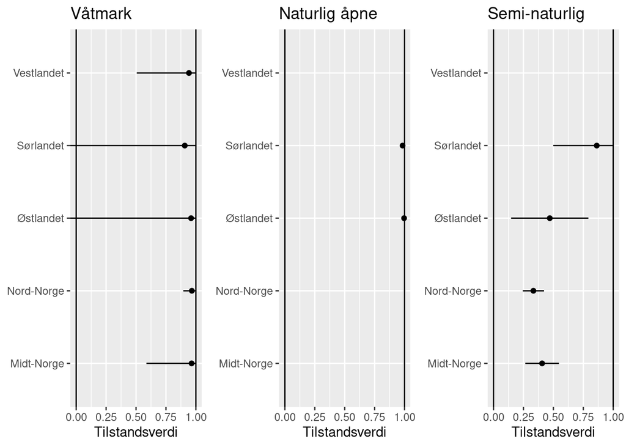

```r
# Make plots of regional index values
getIndicatorPlot <- function(label){
  regions %>%
    left_join(indicatorTable %>%
                filter(Ecosystem == label)) %>%
    mutate(lowError = index-sd,
           upError = index+sd,
           upError = ifelse(upError > 1, 1, upError)) %>%
    ggplot(aes(y=region, x=index)) +
    geom_point() +
    geom_segment(aes(yend=region, x=lowError, xend=upError)) +
    coord_cartesian(xlim=c(0,1)) +
    geom_vline(xintercept = 1) +
    geom_vline(xintercept = 0) +
    labs(x = 'Tilstandsverdi') +
    theme(axis.title.y=element_blank()) +
    ggtitle(label)
}

i1 <- getIndicatorPlot('Våtmark')
i2 <- getIndicatorPlot('Naturlig åpne')
i3 <- getIndicatorPlot('Semi-naturlig')

indicatorGraphFig <- grid.arrange(i1, i2, i3, ncol=3, widths=c(1,1,1), padding = unit(0, "line"), newpage = T)
```

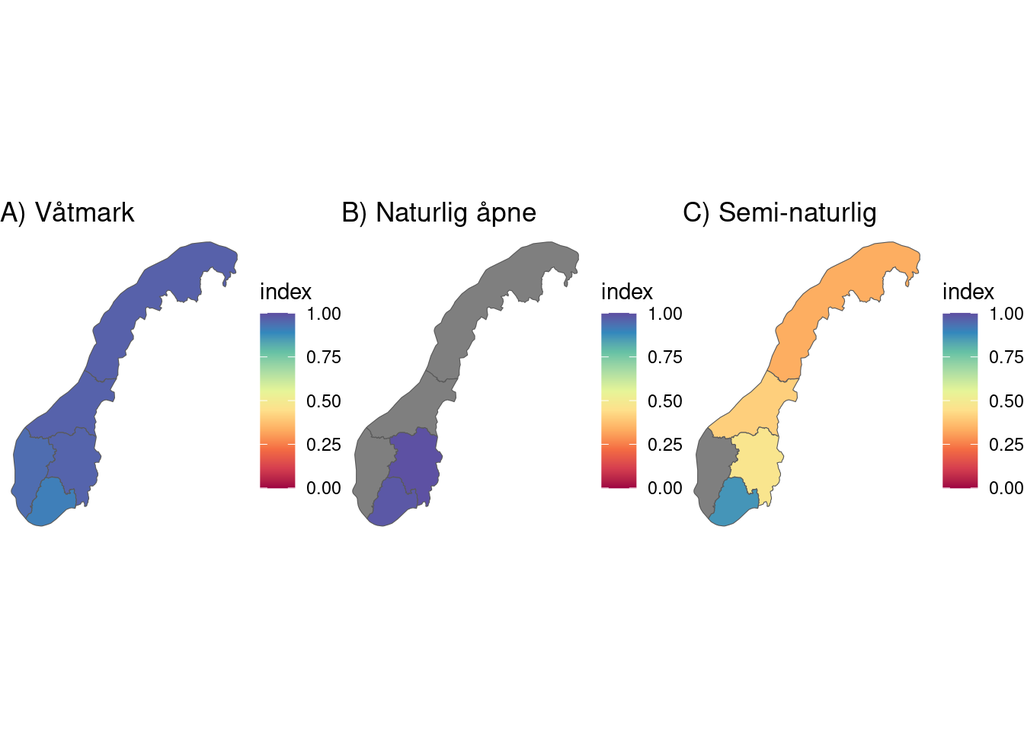

Maps displaying scaled encroachment indicator values on a regional level

```r
# Make maps of regional index values
getIndicatorMap <- function(data, label){
  regions %>%
    left_join(data) %>%
    ggplot() +
    geom_sf(aes(fill=index)) +
    scale_fill_gradientn(colors=brewer.pal(10, 'Spectral'),
                         limits = c(0,1))+
    ggtitle(label)+
    theme_void()
}

m1 <- getIndicatorMap(vaatmarkTable, 'A) Våtmark')
m2 <- getIndicatorMap(aapneTable, 'B) Naturlig åpne')
m3 <- getIndicatorMap(semiTable, 'C) Semi-naturlig')

indicatorGMapFig <- grid.arrange(m1, m2, m3, ncol=3, widths=c(1,1,1), padding = unit(0, "line"), newpage = T)
```

### 10.5 Uncertainty and validation

## 11. Export file

“We will export gjengroing indicator values at three levels: - polygon level - 50km grid level - regional level”

```r
ecosysttypes <- c("vaatmark", "aapne","semi")

for(i in 1:length(ecosysttypes)) {

    ecosysttype <- ecosysttypes[i]

    # Polygon level
    ecosysttypeIndexPolySpat <- get(paste0(ecosysttype,"IndexPolySpat"))
    ecosysttypeIndexPolySpat  %>%
    #mutate(area = as.numeric(st_area(geometry)))%>%
    #filter(area > 7500) %>%
    mutate(id = `system:index`,
           region = region,
           vegZn = vegClimZoneLab) %>%
    dplyr::select(-"system:index", -vegClimZoneLab, -elevation) %>%
    st_write(paste0('/data/P-Prosjekter2/412421_okologisk_tilstand_2024/Ida/Export/', ecosysttype,"_index.shp"), append=FALSE)

    # Grid level
    ecosysttypeIndexGrid <- get(paste0(ecosysttype,"IndexGrid"))
    ecosysttypeIndexGrid %>%
    st_write(paste0('/data/P-Prosjekter2/412421_okologisk_tilstand_2024/Ida/Export/', ecosysttype,"_index_grid.shp"), append=FALSE)

    # Region level
    ecosysttypeIndexRegion <- get(paste0(ecosysttype,"IndexRegion"))
    ecosysttypeIndexRegion %>%
    st_write(paste0('/data/P-Prosjekter2/412421_okologisk_tilstand_2024/Ida/Export/', ecosysttype,"_index_region.shp"), append=FALSE)


}
```